# Market Equilibrium as Global Interference

Author

Jackson M Luckey

# 1 Introduction

Standard causal inference methods assume that the potential outcomes of a unit are unaffected by the treatment assignment of every other unit. The violation of this assumption is called interference. A classic example is vaccination, where the vaccination of others in the community reduces the spread of disease among all members of the community. The classical approach for handling interference is to partition units into groups such that all interference occurs within groups (Hudgens and Halloran 2008; Drew Dimmery 2025). The “General” portion of Figure 1 shows an example where interference can be isolated by clustering units into groups. Another set of approaches isolate social spillovers by partitioning the social network into subgraphs (Aronow and Samii 2017; Ugander et al. 2013). Markets, however, bring interference that cannot be tackled with either of these sets of approaches. Market equilibrium is determined by all sources of supply and demand, causing the treatment of any unit to interfere with the outcomes of all units. The “Market Equilibrium” portion of Figure 1 shows this interference structure. Under this global interference setting, it is not possible to cluster units into groups or subgraphs to isolate interference. On the other hand, knowing that the interference is channeled through the price effect provides sufficient structure for alternative approaches (Wager and Xu 2020; Munro, Kuang, and Wager 2025).

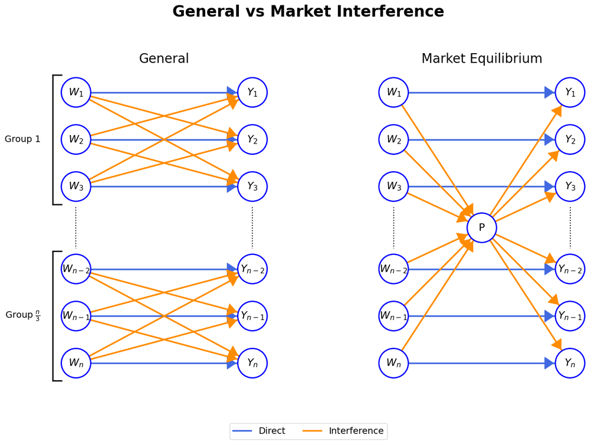

Figure 1: In the general interference setting, the treatment assignment of a unit affects the outcomes of some other units directly. In this figure, interference between units is clustered in groups of 3. In markets, the treatment assignment of all units interferes with the potential outcomes of all units through the price effect (represented as P). This figure was inspired by a sketch in Stefan Wager (2021)’s talk.

The traditional approach to experimentation in two-sided marketplaces starts by segmenting the marketplace into independent submarkets. For example, a ridesharing platforms could treat New York City and San Francisco as separate submarkets. After segmentation, the platform can experiment globally within each submarket, typically with a bandit. This approach has many drawbacks. It requires the marketplace to have plausibly independent submarkets, which is not true for many markets. It is slow to converge. It has high opportunity costs as exploration requires globally suboptimal pricing. Finally, it requires strong assumptions for pooling learning across submarkets (Wager and Xu 2020; Stefan Wager 2020).

In contrast, Wager and Xu (2020) exploits the structure of interference being channeled through the price effect to design an experiment framework that allows for local experimentation in a two-sided marketplace despite global interference. In their model, global interference is through “demand cannibalization”: changes in the price level $p$ cause changes in the proportion of active suppliers $\mu$, which cause changes in expected demand per active supplier $q$, which changes supplier’s decision to become active, changing the proportion of active suppliers $\mu$ again. This feedback loop makes modeling market equilibrium extremely challenging (Stefan Wager 2020). Wager and Xu (2020) solves this problem with the following key ideas:

1. In a sufficiently large market, individual behavior has a very small effect on the overall market equilibrium, meaning that you can experiment on one individual without significant global interference (see Section 3.1).
2. Experimenting with individual-level price perturbations that cancel each out in the aggregate keeps the market equilibrium the same (see Section 4.1).
3. Building on the first two ideas, a small change in price for a specific individual will only affect that individual’s decision of whether or not to enter the market, allowing us to estimate the marginal response to a change in price $\triangle(p)$ (see Section 4.2).
4. Market equilibrium can be simplified to supply, demand, and the elasticities of supply with respect to demand and vice versa (see Section 3). These two elasticities are the marginal response to a change in price $\triangle(p)$. This approach builds on the sufficient statistics literature, where economists reduce intractable structural models to a small number of statistical relationships that represent elasticities (Chetty 2008).

In a sufficiently large market where demand[^1] is exogenous, these ideas enable efficient local experimentation despite global interference from market equilibrium. The goal of experimentation with the methodology is to find the optimal payment $p^*$ at which the platform’s utility is maximized while minimizing the opportunity cost incurred by experimentation (i.e. regret).

# 2 Market Mechanics

In the paper’s setup, the market consists of exogenous demand (i.e. not affected by supply) and a fixed pool of suppliers that can choose to become active on any given day (i.e. there is no market entry or exit). On each day:

1. Demand $D_a$ and demand per supplier $d_a$ is determined by randomly sampling a global state $A$ from the set of global states $\mathbfcal{A}$.
2. The platform chooses a payment policy $\pi$ and draws the supplier-level payments $P_i \sim \pi$.
3. Each supplier learns the payment policy $\pi$ and their payment $P_i$ and decides whether to be active using their choice function $f_{B_i}$, where $B_i$ is supplier $i$’s opportunity cost of entering the market that day (see Section 2.2).
4. The platform randomly allocates demand among active suppliers using the allocation function $\Omega$/$\omega$ (see Section 2.1).
5. The platform receives utility based on the difference between revenue from each unit of demand served and payments made to suppliers. In the simplest case, the platform receives $\gamma$ for each unit of demand served.

When deciding the payment policy $\pi$, the market platform knows its own utility function ($R$ and $r$), the market allocation mechanism ($\Omega$ and $\omega$), and the payment scheme ($\pi$), but does not know the global state ($A$), demand ($D$), or supplier behavior ($f_{B_i}$) in advance. The methodology assumes that random variables are independent across time points and independent from one another within time points. This rules out time series effects through $A$[^2].

## 2.1 Allocation of Demand

Allocation of demand to active suppliers is done at random using an allocation function $\Omega$. Allocation functions must fulfill the following properties:

- Smooth: A small change in expected demand per supplier should make a small change in demand allocated per supplier.
- Concave: The marginal difficultly of matching an additional unit of demand cannot decrease.
- Non-Decreasing: The more demand per supplier, the more demand each supplier must be allocated.
- $\lim_{x \rightarrow 0} \omega(x) = 0$: If there is no demand, suppliers cannot be allocated demand.
- $\lim_{x \rightarrow \infty} \omega(x) \leqslant 1$: Suppliers cannot supply more than their capacity.
- $\lim_{x \rightarrow 0} \omega'(x) \leqslant 1$: When demand is low relative to supply, the allocation rate cannot grow faster than demand.

When the market is large, such an allocation function converges to $\omega(D = d, T = t)$ when the whose behavior is only a function of the ratio between demand the number of active suppliers. Figure 2 shows an example of a well-behaved allocation function, Parallel Finite Capacity Queues, where demand is randomly allocated among suppliers conditional on the suppliers not already having $L$ units of demand in their queue already (Wager and Xu 2020). The simulation in this paper uses this function with the queue length $L$ set to 5.

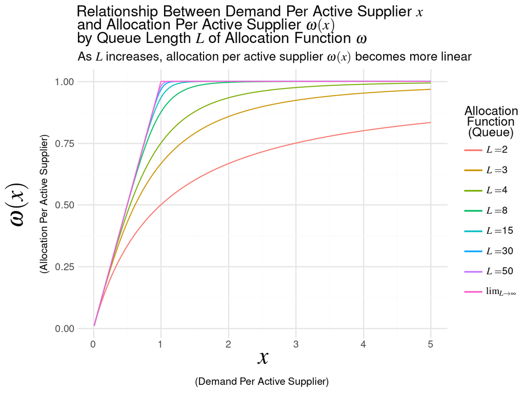

Figure 2: Wager and Xu (2020) uses Parallel Finite Capacity Queues as an example of a well-behaved allocation function. This figure shows that as queue length $L$ increases, the allocation per active supplier $\omega(x)$ becomes more and more linear. In the limit $\lim_{L \rightarrow \infty}$, $\omega(x)$ allocates demand linearly: demand allocated per active supplier is literally demand per active supplier until demand is greater than maximum possible supply ($x = 1$).

## 2.2 Supplier’s Choice

When deciding whether to enter the market, suppliers know the market state $A$ and their potential payment $P_i$. The suppliers decision to become active is given by (3.6 in Wager and Xu (2020)):

$$\mu_{a}^{(n)} (\pi) = \mathbb{P}_{\pi} [Z_i = 1 | A = a] = \mathbb{E} [\underbrace{f_{B_i} (P_i \mathbb{E}_{\pi} [\Omega (D, T) | A = a])}_{\text{Supplier $i$'s Choice}} | A = a]$$

where:

The choice function $f_{B_i}(x)$ determines whether supplier $i$ with opportunity cost $B_i$ becomes active when expected revenue in equilibrium for an active supplier is $x$. The function must be monotonically non-decreasing and have a uniformly bounded second derivative. A good example is the logistic choice function (3.7 in Wager and Xu (2020)):

$$\mathbb{P}[Z_i = 1 | P_i, \pi, A] = \left( 1 + e^{-\alpha (P_i \mathbb{E}_{\pi} [\Omega (D, T) | A] - B_i)} \right)^{-1}$$

The simulation in this paper uses the logistic choice function.

# 3 Market Equilibrium as Key Statistics

The methodology simplifies the market equilibrium to three key statistics:

- $\mu(p)$: The proportion of suppliers that are active at the price level $p$.
- $q(\mu)$: The expected demand allocated per active supplier when $\mu$ proportion of suppliers are active.
- $\triangle(p)$: The marginal response of a supplier to changes in the price level $p$ holding the rest of the market fixed.

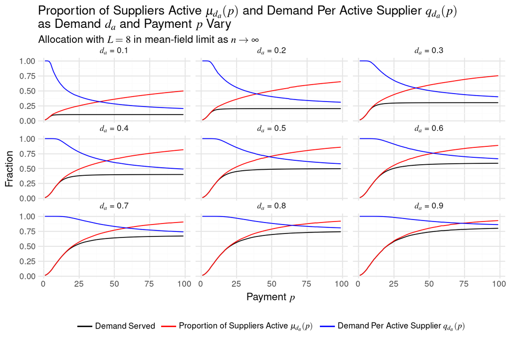

Figure 3: Within a given level of $d_a$, the proportion of suppliers that are active and the proportion of demand served increases as the expected payment $p$ increases. Intuitively, the proportion of suppliers that are active and the expected demand allocated per active supplier are negatively correlated. The proportion of demand served stops increasing at a lower payment level than the proportion of suppliers that are active. As $d_a$ increases, the proportion of demand served and proportion of suppliers that are active increases for any payment $p$ while demand per active supplier decreases less as $p$ increases.

## 3.1 Mean Field Analysis

Wager and Xu (2020) relies on mean-field analysis. As the the number of suppliers $n$ increases, the law of large numbers causes randomness from individual suppliers to average out, eliminating local randomness and leaving only global randomness from the state $A$. Furthermore, interference from any single supplier diminishes, making supplier behavior increasingly independent from one another. In the mean-field ($\lim_{n \rightarrow \infty}$), supplier behavior is asymptotically independent and stochasticity comes exclusively from the global state $A$. Under the mean-field analysis, the key statistics underpinning the market model converge to limiting functions, making the quantities deterministic functions:

- $\lim_{n \rightarrow \infty} \mu_{a}^{(n)} (p) = \mu_{a} (p)$: In a sufficiently large market, the proportion of suppliers that are active becomes $\mu$ (conditional on global state $A$ and payment $p$).
- $\lim_{n \rightarrow \infty} q_{a}^{(n)} (\mu) = \omega \left( \frac{d_a}{\mu} \right)$: In a sufficiently large market, the demand allocated per active supplier is the demand per supplier divided by the proportion of suppliers that are active.
- $\lim_{n \rightarrow \infty} u_{a}^{(n)} (p) = u_{a} (p) = \left( r \left( \frac{d_a}{\mu_a (p)} \right) - p \omega \left( \frac{d_a}{\mu_a (p)} \right) \right) \mu_{a} (p)$: In a sufficiently large market, the platform utility per supplier is the proportion of suppliers that are active times the difference between revenue per active supplier and payments per active suppliers.
- $\lim_{n \rightarrow \infty} (q_{a}^{(n)})' (\mu) = -\omega' \left( \frac{d_a}{\mu} \right) \frac{d_a}{\mu^2}$: In a sufficiently large market, increasing supplier participation decreases each supplier’s allocation.

# 4 Experiment Design

## 4.1 Price Perturbations

Supplier payments are randomly perturbed by $\zeta \epsilon_{it}$, where $\zeta$ is a small constant and $\epsilon_{it}$ is uniformly sampled from $\{-1, 1\}$. In words, on day $t$ approximately half of suppliers are offered the payment $p_t - \zeta$ and the other half are offered $p_t + \zeta$. These perturbations cancel each other out ($\mathbb{E}[p_t + \zeta \epsilon_{it}] = p_t$), so they do not affect the market equilibrium. As the number of suppliers $n$ increases, smaller values of $\zeta$ are sufficient for estimating the marginal response. Furthermore, the symmetry causes the cost of experimentation to mostly cancel out–for every supplier paid an extra $\zeta$ another supplier is paid $\zeta$ less. This makes experimentation extremely low cost in large markets relative to global experimentation methods.

## 4.2 Marginal Response

Regressing $Z_{it}$ on $\epsilon_{it}$ gives the marginal response $\triangle(p)$, which measures how sensitive[^3] suppliers are to changes in payments when equilibrium is held fixed. The marginal response $\triangle(p)$ is very close to the direct effect of changing $p$ (Stefan Wager 2021).

As we know the allocation function $\omega$, we can estimate the global (i.e. including feedback effects in market equilibrium) elasticity of supply with respect to $p$ with (basically 3.20 in Wager and Xu (2020)):

$$\frac{d \mu(p)}{d p} = \triangle_a(p) \left( 1 + \frac{p d_a \triangle_a(p) \omega'\left(\frac{d_a}{\mu_a(p)}\right)}{\mu_a(p)^2 \omega\left(\frac{d_a}{\mu_a(p)}\right)} \right)^{-1}$$

The global elasticity, $\frac{d \mu(p)}{d p}$, is used to update $p$ via gradient ascent.

The difference between $\triangle(p)$ and the global elasticity is the global interference. This is related to the indirect effect (Stefan Wager 2021). Global interference is a function of (basically 3.21 in Wager and Xu (2020)):

$$\underbrace{\frac{p \triangle_a(p)}{\mu_a(p)}}_{\text{Marginal Sensitivity}}
\quad \times \quad
\underbrace{\frac{d_a}{\mu_a(p)} \frac{\omega' \left(\frac{d_a}{\mu_a(p)}\right) }{\omega \left(\frac{d_a}{\mu_a(p)}\right) }}_{\text{Matching Elasticity}}$$

The (scaled) marginal sensitivity is small when the marginal response $\triangle(p)$ is small relative to the supply $\mu(p)$. The (scaled) matching elasticity is small when the elasticity of the matching function $\omega$ is small relative to the ratio of supply to demand $\frac{\mu(p)}{d}$. We know matching elasticity is small when demand is significantly larger than supply. If both are not small, then global interference is non-negligible.

# 5 Simulation

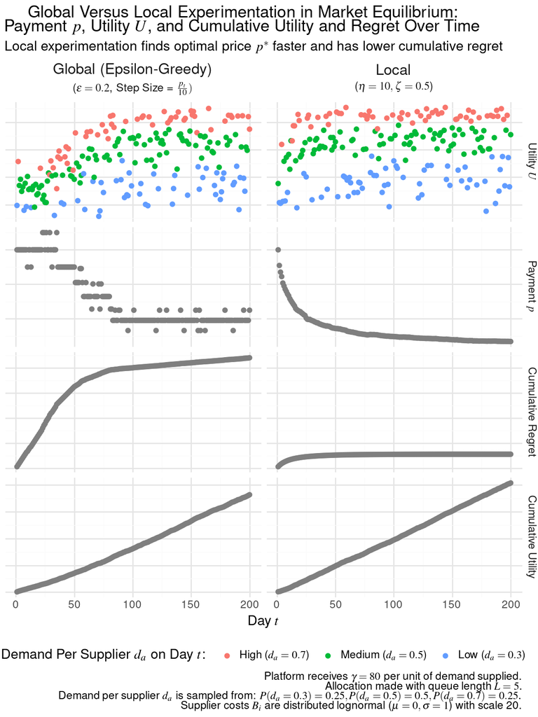

Figure 4: The local experimentation method significantly outperforms global experimentation with a $\epsilon$-greedy bandit. The local method has dramatically lower regret, converges much faster, and gets much closer to the true optimal price level. The cumulative utility charts look similar because potential utility is very high when $p^* \approxeq 23.1$ while $\gamma = 80$ and the number of suppliers is high ($n = 10000$). (Note 1: Demand $D$ should be drawn from $D \sim F_a$, where $a$ is a particular global state $A \in \mathbfcal{A}$, but I simplified to deterministic $D_a$ and therefore $d_a$.) (Note 2: This figure annoyingly has the y-axis labels on the right side and bad y-axis scales due to plotnine only partially implementing ggplot2 features.)

I compared the local experimentation methodology of Wager and Xu (2020) to global experimentation with an epsilon-greedy bandit. I simulated a market over 200 days with $10,000$ suppliers. Figure 4 shows the results of the simulation. As expected, local experimentation significantly outperformed global experimentation.

From ad hoc experimentation, I also found that local experimentation excels relative to global experimentation when the global states are diverse. Without a high $\epsilon$, global bandits can easily spend a significant portion of the days with a highly suboptimal $p$ if the explore days coincide with drawing the same extreme global state. With a high $\epsilon$, regret is high from choosing suboptimal $p$ values on many days. This is only partially mitigated with a high starting epsilon coupled with epsilon decay. On the other hand, with a small market size, a bad initial $p$ value, a relatively small number of timepoints, and similar states in $\mathbfcal{A}$, global bandits sometimes outperform local experimentation because local experimentation either converges slowly or requires a large $\zeta$, which both significantly increase regret. Local experimentation consistently converges much closer to the true $p^*$ than global experimentation given sufficient timepoints.

# 6 Directions for Future Research

## 7 References

Aronow, Peter M., and Cyrus Samii. 2017. “Estimating Average Causal Effects Under General Interference, with Application to a Social Network Experiment.” *The Annals of Applied Statistics* 11 (4). https://doi.org/10.1214/16-AOAS1005.

Chetty, Raj. 2008. “Sufficient Statistics for Welfare Analysis: A Bridge Between Structural and Reduced-Form Methods.” w14399. Cambridge, MA: National Bureau of Economic Research. https://doi.org/10.3386/w14399.

Drew Dimmery. 2025. “Causal Machine Learning Lecture 12: Interference.”

Hudgens, Michael G, and M. Elizabeth Halloran. 2008. “Toward Causal Inference With Interference.” *Journal of the American Statistical Association* 103 (482): 832–42. https://doi.org/10.1198/016214508000000292.

Munro, Evan, Xu Kuang, and Stefan Wager. 2025. “Treatment Effects in Market Equilibrium.” arXiv. https://doi.org/10.48550/arXiv.2109.11647.

Stefan Wager. 2020. “Stefan Wager: Experimenting in Equilibrium.” https://www.youtube.com/watch?v=c7P0-gpP1YQ.

———. 2021. “Stefan Wager: Treatment Effects in Market Equilibrium.” Online Causal Inference Seminar. https://www.youtube.com/watch?v=MW4Kmx9wYmw.

Ugander, Johan, Brian Karrer, Lars Backstrom, and Jon Kleinberg. 2013. “Graph Cluster Randomization: Network Exposure to Multiple Universes.” arXiv. https://doi.org/10.48550/arXiv.1305.6979.

Wager, Stefan, and Kuang Xu. 2020. “Experimenting in Equilibrium.” arXiv. https://doi.org/10.48550/arXiv.1903.02124.

## Footnotes

[^1]: I suspect that making supply fixed and having demand fluctuate would work, but I haven’t thought about it sufficiently, let alone tried setting it up mathematically.
[^2]: I presume that this means that the platform knows predictable time series trends and that $A$ only represents the purely stochastic portion of the global state. I suspect this model could be adapted to condition on both a stochastic global state unknown to the platform and a state known to the model, but I haven’t tried it.
[^3]: I conceptualize this as the local elasticity of supply with respect to price $p$.